# Script_eval_ex2

Jean-François Parriaud

2023-03-12

```r
# Chargement des packages
library(dplyr)
library(sf)
library(spdep)
library(RColorBrewer)
```

# Exercice 1 TP6:

## Question 1:

Les données carroyées sont sous la forme d’un géopackage, elles sont lues via l’instruction st_read. Le nombre de ménages pauvres est contenu dans la variable Men_pauv, le nombre de ménages dans la variable Men. Le taux de ménages pauvres est obtenu en effectuant le quotient de la première par la deuxième, et ajouté dans le fichier de données avec la fonction transform.

```r
# Import des données carroyées
data<-st_read("./data/lyon.gpkg")
# Ajout de la part de ménages pauvres
data <- data %>%
  transform(taux_men_pauv = Men_pauv/Men)
```

## Question 2:

On commence par charger le fonds de commune. Celui-ci utilise le système de projection WGS 84, on passe en Lambert 93 par la commande st_transform. Enfin on sélectionne la ville qui nous intéresse, Lyon, à l’aide de son code postal. La superposition des données carroyées et du fonds de la commune permet de constater que les carreaux dépassent les frontières communales. Si les carreaux avaient été limités aux frontières communales, on aurait couru le risque d’avoir des carreaux en bordure ne contenant que très peu de données, et par conséquent sujets à de fortes fluctuations statistiques. Pour des grandes villes, on peut raisonnablement émettre une hypothèse de continuum, i.e. qu’il n’y a pas de différence notable de part et d’autre de la frontière entre les deux communes. D’autre part, certains carreaux semblent se situer entièrement en dehors des frontières communales. C’est probablement dû au fait que la géométrie utilisée pour notre fonds de commune est ici simpliste. Avec une géométrie plus fine, ces carreaux auraient eu une petite partie commune avec la ville.

```r
# Import du fonds de commune
france<-st_read("./fonds/commune_franceentiere_2021.shp")
# Changement du sustème de projection
france <- france %>%
  st_transform(2154)
st_crs(france)
```

```
## Coordinate Reference System:
##   User input: EPSG:2154
##   wkt:
## PROJCRS["RGF93 v1 / Lambert-93",
##     BASEGEOGCRS["RGF93 v1",
##         DATUM["Reseau Geodesique Francais 1993 v1",
##             ELLIPSOID["GRS 1980",6378137,298.257222101,
##                 LENGTHUNIT["metre",1]]],
##         PRIMEM["Greenwich",0,
##             ANGLEUNIT["degree",0.0174532925199433]],
##         ID["EPSG",4171]],
##     CONVERSION["Lambert-93",
##         METHOD["Lambert Conic Conformal (2SP)",
##             ID["EPSG",9802]],
##         PARAMETER["Latitude of false origin",46.5,
##             ANGLEUNIT["degree",0.0174532925199433],
##             ID["EPSG",8821]],
##         PARAMETER["Longitude of false origin",3,
##             ANGLEUNIT["degree",0.0174532925199433],
##             ID["EPSG",8822]],
##         PARAMETER["Latitude of 1st standard parallel",49,
##             ANGLEUNIT["degree",0.0174532925199433],
##             ID["EPSG",8823]],
##         PARAMETER["Latitude of 2nd standard parallel",44,
##             ANGLEUNIT["degree",0.0174532925199433],
##             ID["EPSG",8824]],
##         PARAMETER["Easting at false origin",700000,
##             LENGTHUNIT["metre",1],
##             ID["EPSG",8826]],
##         PARAMETER["Northing at false origin",6600000,
##             LENGTHUNIT["metre",1],
##             ID["EPSG",8827]]],
##     CS[Cartesian,2],
##         AXIS["easting (X)",east,
##             ORDER[1],
##             LENGTHUNIT["metre",1]],
##         AXIS["northing (Y)",north,
##             ORDER[2],
##             LENGTHUNIT["metre",1]],
##     USAGE[
##         SCOPE["Engineering survey, topographic mapping."],
##         AREA["France - onshore and offshore, mainland and Corsica."],
##         BBOX[41.15,-9.86,51.56,10.38]],
##     ID["EPSG",2154]]
```

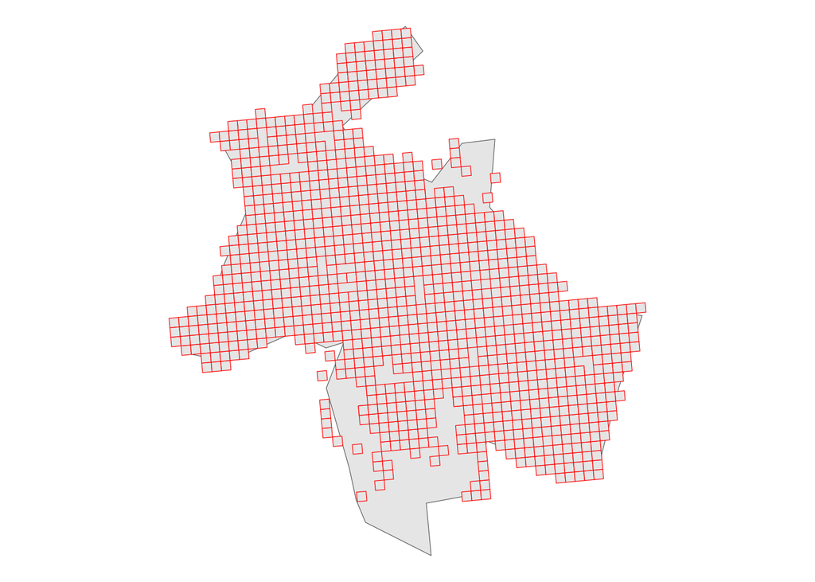

```r
# Sélection de la ville de Lyon
lyon<-france %>%
  filter(code=="69123")
# Nettoyage: le fichier france ne nous sert plus, autant l'enlever de la mémoire
rm(france)

# On superpose les données carroyées au fonds de la commune.
library(ggplot2)
ggplot() +
  geom_sf(data = lyon)+
  geom_sf(data = data["taux_men_pauv"],color="red") +
  theme_void()
```

## Question 3:

On affiche les statistiques du taux de ménages pauvres. D’abord le résumé:

```r
summary(data$taux_men_pauv)
```

```
##    Min. 1st Qu.  Median    Mean 3rd Qu.    Max.
## 0.00000 0.07937 0.12426 0.13537 0.17227 0.55556
```

Puis la boite à moustaches. On peut constater que la queue de la distribution est très étendue.

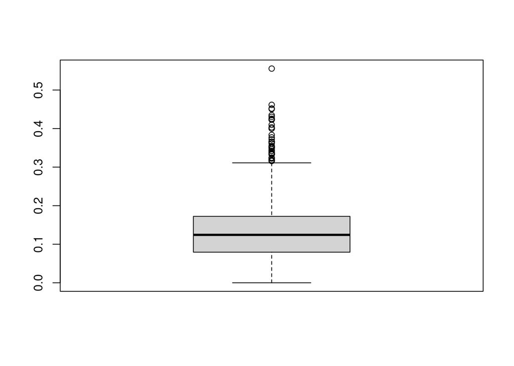

```r
boxplot(data$taux_men_pauv)
```

On effectue une représentation spatiale des données sur le taux de ménages pauvres, pour voir s’il y a lieu de suspecter uné éventuelle corrélation spatiale. Dans le cas présent, on observe des regroupements de couleurs vives, associées à un taux plus élevé de ménages pauvres, et des regroupements de couleurs froides, associées à un faible taux de ménages pauvres. Il y a probablement corrélation spatiale positive.

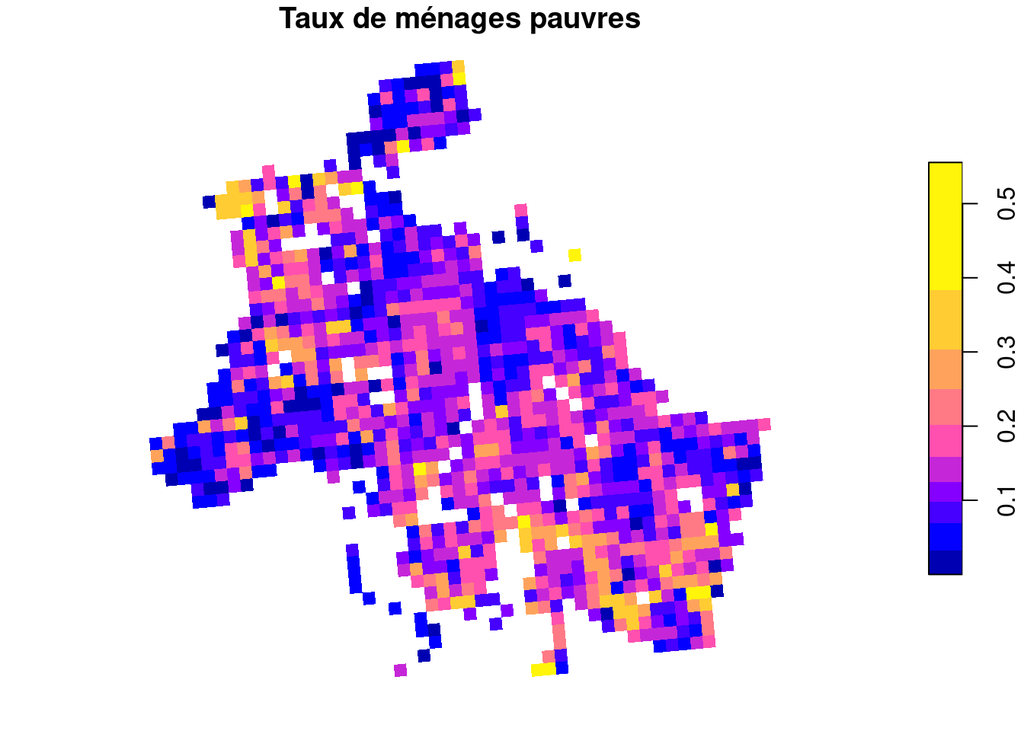

```r
plot(data["taux_men_pauv"],breaks='jenks',border=FALSE,main="Taux de ménages pauvres")
```

### Création de la liste des voisins

On crée la liste des voisins de chaque carreau. Détail surprenant: un carreau ne devrait pas avoir plus de 8 voisins, mais on monte ici à 15!

```r
voisins <- data %>% spdep::poly2nb()
summary(voisins)
```

```
## Neighbour list object:
## Number of regions: 1211
## Number of nonzero links: 10054
## Percentage nonzero weights: 0.6855681
## Average number of links: 8.30223
## 6 regions with no links:
## 45 188 195 233 278 1030
## Link number distribution:
##
##   0   1   2   3   4   5   6   7   8   9  10  11  12  13  14  15
##   6   7  11  24  43  70  78 137 387  90  81 106 112  52   3   4
## 7 least connected regions:
## 17 27 57 205 238 254 1086 with 1 link
## 4 most connected regions:
## 115 813 907 965 with 15 links
```

```r
# Quelque chose cloche dans le nombre de voisins: doublons
```

Les 6 carreaux sans voisins posent problème lors du tracé du diagramme de Moran et lors du calcul de l’indice de Moran. Nous allons devoir les enlever des données.

```r
j<-1
list_avec_voisins <- rep(0,dim(data)[1]-6)
for (i in 1:dim(data)[1]){
  if (voisins[[i]][1]!=0) {
    list_avec_voisins[j]<-i
    j<-j+1
  }
}
data<-data[list_avec_voisins,]
```

Après comparaison des données, il semble que des carreaux aient été dupliqués: par exemple, le 115 et le 813 contiennent exactement les mêmes données et se superposent sur la carte. Le fichier de données est débarrassé des doublons avec la commande distinct.

```r
data2 <- distinct(data)
voisins <- data2 %>% spdep::poly2nb()
summary(voisins)
```

```
## Neighbour list object:
## Number of regions: 1072
## Number of nonzero links: 7472
## Percentage nonzero weights: 0.6502005
## Average number of links: 6.970149
## Link number distribution:
##
##   1   2   3   4   5   6   7   8
##   7  11  26  45  87 108 202 586
## 7 least connected regions:
## 17 27 56 202 234 250 953 with 1 link
## 586 most connected regions:
## 29 42 43 46 47 48 51 52 53 59 60 61 64 65 72 74 75 76 82 83 86 87 91 93 94 96 97 103 104 107 108 109 110 113 114 116 117 120 121 122 123 125 126 128 129 130 131 132 133 134 135 137 145 146 147 150 152 153 154 157 158 159 160 161 162 163 166 167 168 170 171 172 173 175 176 177 178 179 180 181 182 …
```

```r
# Là c'est cohérent!
```

La répartition de ces doublons sur la représentation spatiale ressemble peu à un processus aléatoire. Ce sont 133 carreaux, correspondant à 28783 ménages, qui apparaissent dans ces doublons, sur un total de 239568.

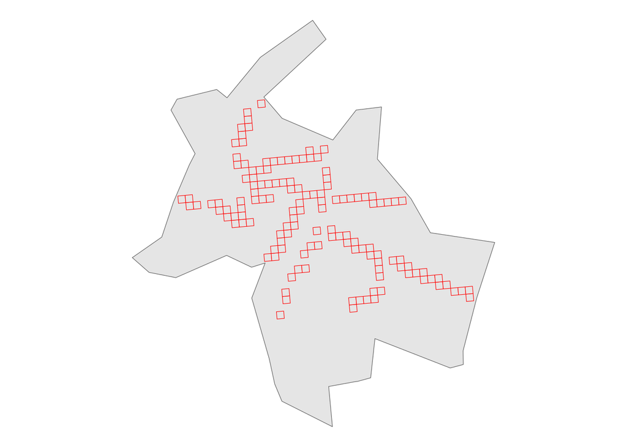

```r
doublons<-data[which(duplicated(data)),]
men_doublons <- sum(doublons$Men)
ggplot() +
  geom_sf(data = lyon)+
  geom_sf(data = doublons["taux_men_pauv"],color="red") +
  theme_void()
```

```r
# La répartition des doublons semble suivre des lignes...
```

## Création des poids

On crée une liste de poids à partir de la liste de voisins.

```r
ponderation <- nb2listw(voisins, zero.policy = TRUE)
```

## Diagramme de Moran

On crée une variable centrée et réduite pour le taux de ménages pauvres. L’histogramme permet de bien visualiser l’étendue de la queue de la distribution.

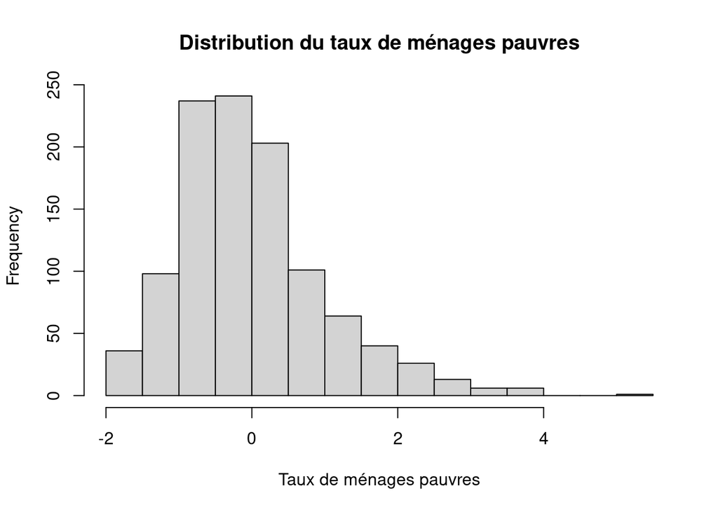

```r
data2 <- data2 %>%
  mutate(taux_men_pauv_std = scale(taux_men_pauv))
test1<-mean(data2$taux_men_pauv_std)   # valeur très faible  -> bien centrée
test2<-sd(data2$taux_men_pauv_std)     # égal à 1   --> bien réduite
hist(data2$taux_men_pauv_std,main="Distribution du taux de ménages pauvres",
     xlab="Taux de ménages pauvres")
```

On trace le diagramme de Moran. On remarque bien une auto-corrélation positive sur le diagramme.

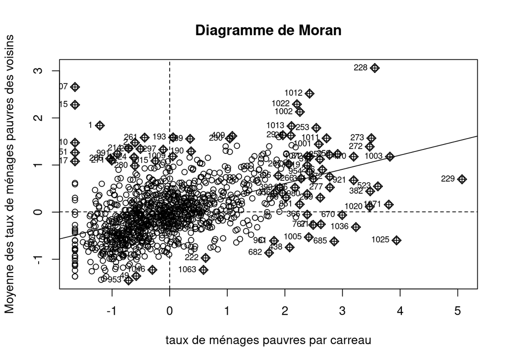

```r
moran.plot(
  as.numeric(data2$taux_men_pauv_std),
  listw = ponderation,
  xlab = "taux de ménages pauvres par carreau",
  ylab = "Moyenne des taux de ménages pauvres des voisins",
  main = "Diagramme de Moran"
)
```

## Calcul de l’indice de Moran

On calcule l’indice de Moran pour estimer la significativité de l’auto-corrélation. L’hypothèse nulle (absence d’auto-corrélation) est nettement rejetée. L’autocorrélation positive observée précédemment est significative.

```r
moran.test(data2$taux_men_pauv_std, ponderation, randomisation = TRUE)
```

```
##
##  Moran I test under randomisation
##
## data:  data2$taux_men_pauv_std
## weights: ponderation
##
## Moran I statistic standard deviate = 17.829, p-value < 2.2e-16
## alternative hypothesis: greater
## sample estimates:
## Moran I statistic       Expectation          Variance
##      0.3009404292     -0.0009337068      0.0002866751
```

## Effet du type de voisinage

Précédemment le nombre de voisins pour chaque carreau était déterminé avec l’option par défaut: queen = TRUE, pour laquelle le nombre de voisins maximal était de 8. Nous allons maintenant le calculer en désactivant cette option.

```r
voisins2 <- data2 %>% spdep::poly2nb(queen=FALSE)
summary(voisins2)
```

```
## Neighbour list object:
## Number of regions: 1072
## Number of nonzero links: 3794
## Percentage nonzero weights: 0.3301473
## Average number of links: 3.539179
## 6 regions with no links:
## 17 56 234 250 262 953
## Link number distribution:
##
##   0   1   2   3   4
##   6  20 100 210 736
## 20 least connected regions:
## 19 22 27 63 78 100 156 198 202 207 212 213 214 219 228 240 260 261 279 971 with 1 link
## 736 most connected regions:
## 29 30 33 34 36 38 42 43 46 47 48 51 52 53 59 60 61 64 65 70 71 72 74 75 76 82 83 86 87 91 92 93 94 96 97 103 104 107 108 109 110 113 114 115 116 117 119 120 121 122 123 125 126 128 129 130 131 132 133 134 135 137 140 145 146 147 150 151 152 153 154 157 158 159 160 161 162 163 166 167 168 170 171 …
```

Il faut à nouveau enlever les carreaux sans voisin: ceux qui auparavant n’avaient de voisin qu’en diagonale.

```r
j<-1
list_avec_voisins <- rep(0,dim(data2)[1]-6)
for (i in 1:dim(data2)[1]){
  if (voisins2[[i]][1]!=0) {
    list_avec_voisins[j]<-i
    j<-j+1
  }
}
data_king<-data2[list_avec_voisins,]
voisins2 <- data_king %>% spdep::poly2nb(queen=FALSE)
summary(voisins2)
```

```
## Neighbour list object:
## Number of regions: 1066
## Number of nonzero links: 3794
## Percentage nonzero weights: 0.3338742
## Average number of links: 3.559099
## Link number distribution:
##
##   1   2   3   4
##  20 100 210 736
## 20 least connected regions:
## 19 22 27 63 78 100 156 198 202 207 212 213 214 219 228 240 260 261 279 971 with 1 link
## 736 most connected regions:
## 29 30 33 34 36 38 42 43 46 47 48 51 52 53 59 60 61 64 65 70 71 72 74 75 76 82 83 86 87 91 92 93 94 96 97 103 104 107 108 109 110 113 114 115 116 117 119 120 121 122 123 125 126 128 129 130 131 132 133 134 135 137 140 145 146 147 150 151 152 153 154 157 158 159 160 161 162 163 166 167 168 170 171 …
```

Cette nouvelle définition du voisinage donne lieu à un nouveau diagramme de Moran, assez semblable au premier.

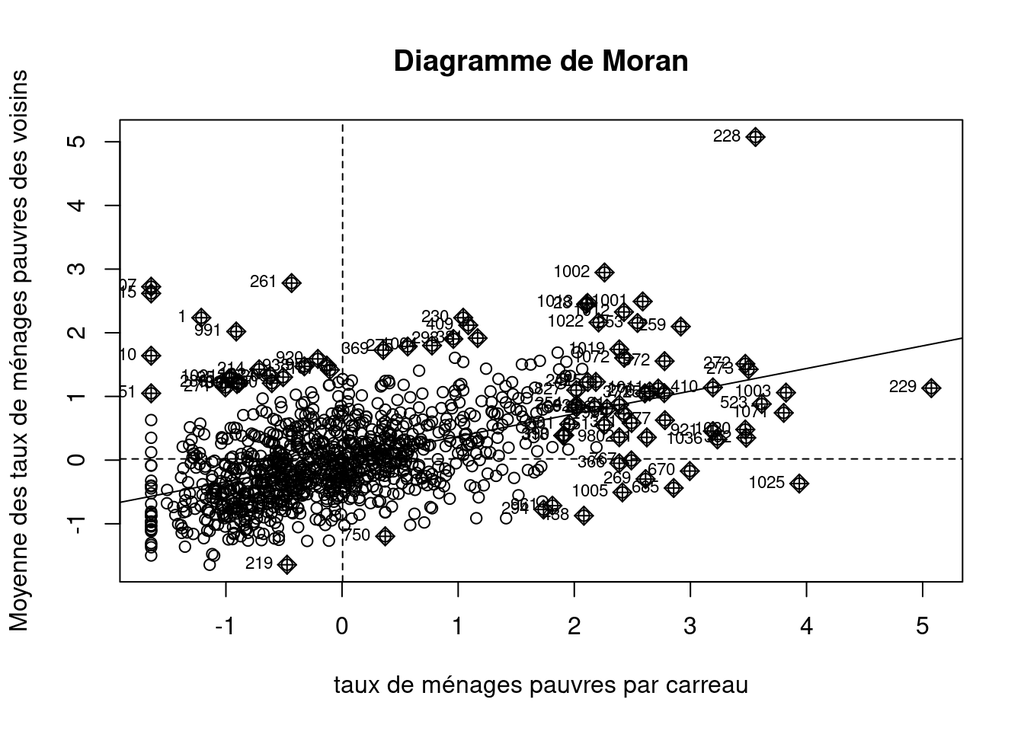

```r
ponderation2 <- nb2listw(voisins2, zero.policy = TRUE)
moran.plot(
  as.vector(data_king$taux_men_pauv_std),
  listw = ponderation2,
  xlab = "taux de ménages pauvres par carreau",
  ylab = "Moyenne des taux de ménages pauvres des voisins",
  main = "Diagramme de Moran"
)
```

Nous pouvons aussi réeffectuer le calcul de l’indice de Moran avec cette option désactivée. La nouvelle valeur reste nettement significative: quelle que soit la définition du voisinage, on constate une corrélation spatiale positive.

```r
moran.test(data_king$taux_men_pauv_std, ponderation2, randomisation = TRUE)
```

```
##
##  Moran I test under randomisation
##
## data:  data_king$taux_men_pauv_std
## weights: ponderation2
##
## Moran I statistic standard deviate = 15.203, p-value < 2.2e-16
## alternative hypothesis: greater
## sample estimates:
## Moran I statistic       Expectation          Variance
##      0.3556099138     -0.0009389671      0.0005500285
```

# Indicateurs d’autocorrélation locaux (LISA)

Commençons par calculer les LISA. On peut constater que la moyenne des indicateurs Ii est positive, conformément à la corrélation positive observée avec l’indice global.

```r
lyon_rev_lisa <- as.vector(data2$taux_men_pauv_std) %>% spdep::localmoran(listw=ponderation)
summary(lyon_rev_lisa)
```

```
##        Ii                E.Ii                Var.Ii             Z.Ii
##  Min.   :-4.37007   Min.   :-2.407e-02   Min.   :0.00000   Min.   :-4.5651
##  1st Qu.:-0.02266   1st Qu.:-1.010e-03   1st Qu.:0.01251   1st Qu.:-0.2730
##  Median : 0.07400   Median :-3.302e-04   Median :0.05238   Median : 0.5921
##  Mean   : 0.30094   Mean   :-9.337e-04   Mean   :0.16922   Mean   : 0.6007
##  3rd Qu.: 0.44570   3rd Qu.:-8.411e-05   3rd Qu.:0.16212   3rd Qu.: 1.5449
##  Max.   :10.90298   Max.   : 0.000e+00   Max.   :6.27766   Max.   : 6.7011
##  Pr(z != E(Ii))
##  Min.   :0.00000
##  1st Qu.:0.08017
##  Median :0.32652
##  Mean   :0.38375
##  3rd Qu.:0.65073
##  Max.   :0.99909
```

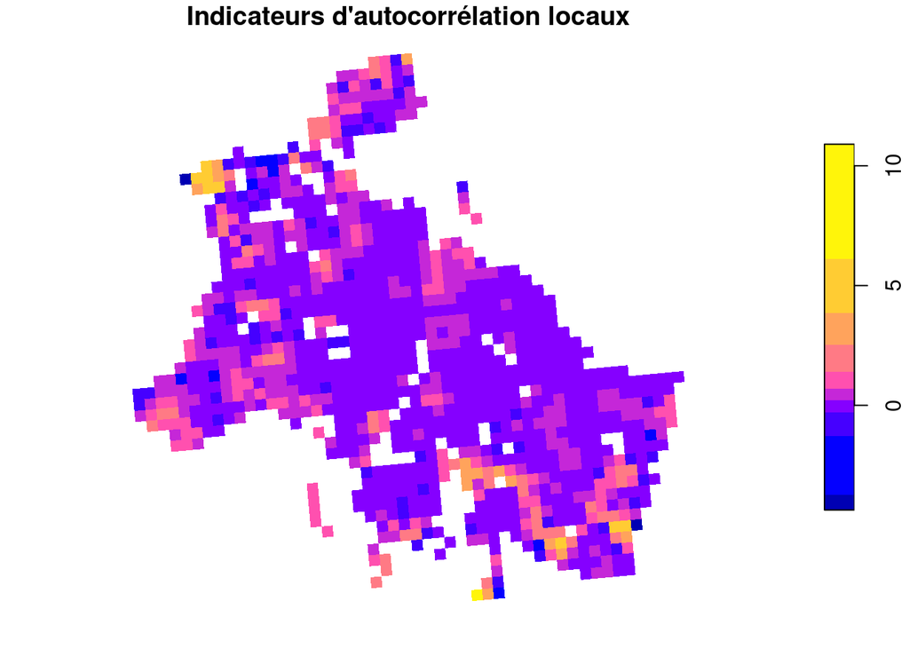

```r
LISA<-data.frame(lyon_rev_lisa[,1])
data2 <- cbind(data2,LISA)%>%
  rename("LISA"="lyon_rev_lisa...1.")
plot(data2["LISA"],breaks='jenks',border=FALSE,main="Indicateurs d'autocorrélation locaux")
```

Nous allons maintenant visualiser les pvaleurs des indices d’autocorrélation locaux. Nous pouvons constater que les zones avec autocorrélation positive mentionnées précédemment correspondent toutes à des faibles pvaleurs, ce qui signifie que l’autocorrélation est significative.

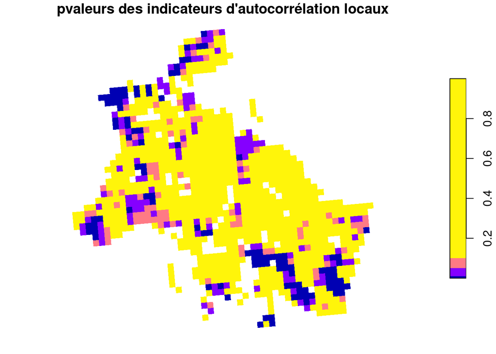

```r
LISA<-data.frame(lyon_rev_lisa[,5])
data2 <- cbind(data2,LISA)%>%
  rename("LISA_PVAL"="lyon_rev_lisa...5.")
plot(data2["LISA_PVAL"],breaks=c(0,0.01,0.05,0.1,1),border=FALSE,main="pvaleurs des indicateurs d'autocorrélation locaux")
```